# VirtualShip

NMF Roadshow | 2026

[figure not shown]

- Open-source **VirtualShip** software provides scientists with an authentic experience of sea-going research anywhere in the global ocean.
- Simulates measurements in a *digital* ocean as if they are coming from real-life oceanographic instruments
  - Including CTDs, ADCPs, Drifters, Argo floats, and more.

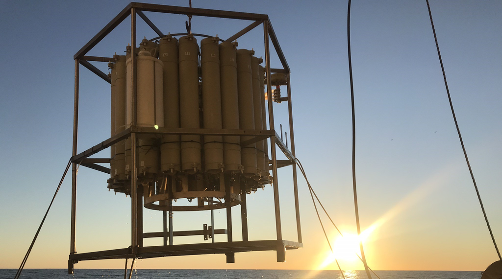

CTD (NIOZ)

[figure not shown]

ADCP (Nortek)

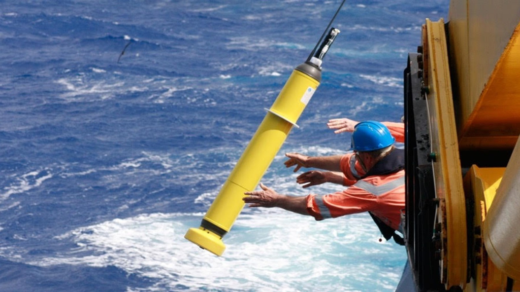

Argo (NOAA)

[figure not shown]

- VirtualShip is a powerful tool for:
  - **Research** (testing new instrument designs, sampling strategies, OSSEs, etc.)

**Note**

Today, I am talking about the VirtualShip *software*. We also run the **VirtualShip Classroom**, which incorporates educational resources and VR to build an authentic learning experience for students (at UU and soon beyond).

## VirtualShip internals

[figure not shown]

- - Lagrangian trajectory framework
  - Instruments have behaviours via customisable, extensible `kernels`
  - VirtualShip = `kernel`s + configuration + digital ocean

[figure not shown]

- - The digital ocean
  - Data ingestion is by default ‘streamed’ via `copernicusmarine` Python toolbox (on-the-fly)
  - With an option to pre-download to ingest (any gridded forcing data) from disk

## An example expedition 🚢

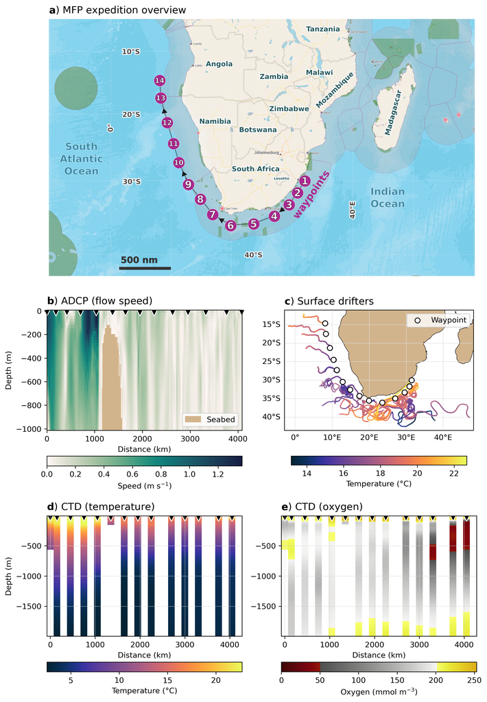

## An example expedition 🚢

Argo Float deployment

[interactive chart not shown]

## VirtualShip applications 🚢

- For researchers:
  - Observing System Simulation Experiments (OSSEs)
    - VirtualShip can help mesh diverse deployments in a digital ocean before spending thousands/millions of € on real-life deployments.
- For complementing real-life expeditions:
  - Plan your expedition in a digital ocean before you go to sea.
  - Real-time adaptive strategies where sampling plans on real-life expedtions are updated based on incoming data and/or forecasts.
- For educators:
  - VirtualShip Classroom (software + open educational resources + VR / 360° videos)

## Links & getting in touch

**Project email**: virtualship@uu.nl

**VritualShip website**: virtualship.parcels-code.org/

**GitHub**: github.com/Parcels-code/virtualship

[figure not shown]

GitHub

[figure not shown]

Website

# Now, a live software demo…

## And now a live VR demo…

[**Live VR Casting →**](https://horizon.meta.com/casting/)